# Prosper Loan Data Exploration

## Preliminary Wrangling

Prosper Loan Data (prosperloanData.csv) represents personal loans requested through Prosper's peer to peer loan servicing network. Each row represents a loan with information on the listing request, loan details, and borrower's credit worthiness.

```python
# import all packages and set plots to be embedded inline
import numpy as np
import pandas as pd
import matplotlib.pyplot as plt
import seaborn as sb

%matplotlib inline
```

### Load Data and Describe

```python
# Load Data from CSV
df = pd.read_csv('prosperloanData.csv')
```

```python
# View first few rows
df.head()
```

|  | ListingKey | ListingNumber | ListingCreationDate | CreditGrade | Term | LoanStatus | ClosedDate | BorrowerAPR | BorrowerRate | LenderYield | ... | LP_ServiceFees | LP_CollectionFees | LP_GrossPrincipalLoss | LP_NetPrincipalLoss | LP_NonPrincipalRecoverypayments | PercentFunded | Recommendations | InvestmentFromFriendsCount | InvestmentFromFriendsAmount | Investors |
| --- | --- | --- | --- | --- | --- | --- | --- | --- | --- | --- | --- | --- | --- | --- | --- | --- | --- | --- | --- | --- | --- |
| 0 | 1021339766868145413AB3B | 193129 | 2007-08-26 19:09:29.263000000 | C | 36 | Completed | 2009-08-14 00:00:00 | 0.16516 | 0.1580 | 0.1380 | ... | -133.18 | 0.0 | 0.0 | 0.0 | 0.0 | 1.0 | 0 | 0 | 0.0 | 258 |
| 1 | 10273602499503308B223C1 | 1209647 | 2014-02-27 08:28:07.900000000 | NaN | 36 | Current | NaN | 0.12016 | 0.0920 | 0.0820 | ... | 0.00 | 0.0 | 0.0 | 0.0 | 0.0 | 1.0 | 0 | 0 | 0.0 | 1 |
| 2 | 0EE9337825851032864889A | 81716 | 2007-01-05 15:00:47.090000000 | HR | 36 | Completed | 2009-12-17 00:00:00 | 0.28269 | 0.2750 | 0.2400 | ... | -24.20 | 0.0 | 0.0 | 0.0 | 0.0 | 1.0 | 0 | 0 | 0.0 | 41 |
| 3 | 0EF5356002482715299901A | 658116 | 2012-10-22 11:02:35.010000000 | NaN | 36 | Current | NaN | 0.12528 | 0.0974 | 0.0874 | ... | -108.01 | 0.0 | 0.0 | 0.0 | 0.0 | 1.0 | 0 | 0 | 0.0 | 158 |
| 4 | 0F023589499656230C5E3E2 | 909464 | 2013-09-14 18:38:39.097000000 | NaN | 36 | Current | NaN | 0.24614 | 0.2085 | 0.1985 | ... | -60.27 | 0.0 | 0.0 | 0.0 | 0.0 | 1.0 | 0 | 0 | 0.0 | 20 |

5 rows × 81 columns

```python
# Rows, Columns
df.shape
```

```
(113937, 81)
```

```python
# Change date column d-types
df['ClosedDate'] = pd.to_datetime(df['ClosedDate'])
df['DateCreditPulled'] = pd.to_datetime(df['DateCreditPulled'])
df['LoanOriginationDate'] = pd.to_datetime(df['LoanOriginationDate'])
```

```python
# Column Structure and completeness information
df.info()
```

```
<class 'pandas.core.frame.DataFrame'>
RangeIndex: 113937 entries, 0 to 113936
Data columns (total 81 columns):
 #   Column                               Non-Null Count   Dtype
---  ------                               --------------   -----
 0   ListingKey                           113937 non-null  object
 1   ListingNumber                        113937 non-null  int64
 2   ListingCreationDate                  113937 non-null  object
 3   CreditGrade                          28953 non-null   object
 4   Term                                 113937 non-null  int64
 5   LoanStatus                           113937 non-null  object
 6   ClosedDate                           55089 non-null   datetime64[ns]
 7   BorrowerAPR                          113912 non-null  float64
 8   BorrowerRate                         113937 non-null  float64
 9   LenderYield                          113937 non-null  float64
```

[output cut: 73 more lines]

```python
# Summary statistics for numeric columns of interest
df[['PercentFunded', 'LoanOriginalAmount', 'MonthlyLoanPayment', 'LP_GrossPrincipalLoss',
    'LP_NetPrincipalLoss', 'Term', 'BorrowerRate', 'LenderYield', 'EstimatedLoss', 'EstimatedReturn',
    'ProsperRating (numeric)', 'ProsperScore']].describe()
```

|  | PercentFunded | LoanOriginalAmount | MonthlyLoanPayment | LP_GrossPrincipalLoss | LP_NetPrincipalLoss | Term | BorrowerRate | LenderYield | EstimatedLoss | EstimatedReturn | ProsperRating (numeric) | ProsperScore |
| --- | --- | --- | --- | --- | --- | --- | --- | --- | --- | --- | --- | --- |
| count | 113937.000000 | 113937.00000 | 113937.000000 | 113937.000000 | 113937.000000 | 113937.000000 | 113937.000000 | 113937.000000 | 84853.000000 | 84853.000000 | 84853.000000 | 84853.000000 |
| mean | 0.998584 | 8337.01385 | 272.475783 | 700.446342 | 681.420499 | 40.830248 | 0.192764 | 0.182701 | 0.080306 | 0.096068 | 4.072243 | 5.950067 |
| std | 0.017919 | 6245.80058 | 192.697812 | 2388.513831 | 2357.167068 | 10.436212 | 0.074818 | 0.074516 | 0.046764 | 0.030403 | 1.673227 | 2.376501 |
| min | 0.700000 | 1000.00000 | 0.000000 | -94.200000 | -954.550000 | 12.000000 | 0.000000 | -0.010000 | 0.004900 | -0.182700 | 1.000000 | 1.000000 |
| 25% | 1.000000 | 4000.00000 | 131.620000 | 0.000000 | 0.000000 | 36.000000 | 0.134000 | 0.124200 | 0.042400 | 0.074080 | 3.000000 | 4.000000 |
| 50% | 1.000000 | 6500.00000 | 217.740000 | 0.000000 | 0.000000 | 36.000000 | 0.184000 | 0.173000 | 0.072400 | 0.091700 | 4.000000 | 6.000000 |
| 75% | 1.000000 | 12000.00000 | 371.580000 | 0.000000 | 0.000000 | 36.000000 | 0.250000 | 0.240000 | 0.112000 | 0.116600 | 5.000000 | 8.000000 |
| max | 1.012500 | 35000.00000 | 2251.510000 | 25000.000000 | 25000.000000 | 60.000000 | 0.497500 | 0.492500 | 0.366000 | 0.283700 | 7.000000 | 11.000000 |

```python
# Check first and last loan dates
df['LoanOriginationDate'].min(), df['LoanOriginationDate'].max()
```

```
(Timestamp('2005-11-15 00:00:00'), Timestamp('2014-03-12 00:00:00'))
```

### Preliminary Data Cleaning

Variable of Interest: LoanStatus

Supporting variables BorrowerRate, EstimatedReturn, ProsperRating, ProsperScore, ListingCategory, LoanOriginalAmount, LoanOriginationDate, CreditScoreRangeLower, CreditScoreRangeUpper, Term

```python
# LoanStatus nulls
df['LoanStatus'].isna().sum()
```

```
0
```

```python
# Data duplicates
df.duplicated().sum()
```

```
0
```

```python
print('BorrowerRate nulls: ', df['BorrowerRate'].isna().sum())
print('EstimatedReturn nulls: ', df['EstimatedReturn'].isna().sum())
print('ProsperRating nulls: ', df['ProsperRating (Alpha)'].isna().sum())
print('CreditGrade nulls: ', df['CreditGrade'].isna().sum())
print('ListingCategory nulls: ', df['ListingCategory (numeric)'].isna().sum())
print('LoanOriginalAmount nulls: ', df['LoanOriginalAmount'].isna().sum())
print('LoanOriginationDate nulls: ', df['LoanOriginationDate'].isna().sum())
print('CreditScoreRangeLower nulls: ', df['CreditScoreRangeLower'].isna().sum())
print('CreditScoreRangeUpper nulls: ', df['CreditScoreRangeUpper'].isna().sum())
print('Term nulls: ', df['Term'].isna().sum())
```

```
BorrowerRate nulls:  0
EstimatedReturn nulls:  29084
ProsperRating nulls:  29084
CreditGrade nulls:  84984
ListingCategory nulls:  0
LoanOriginalAmount nulls:  0
LoanOriginationDate nulls:  0
CreditScoreRangeLower nulls:  591
CreditScoreRangeUpper nulls:  591
Term nulls:  0
```

**Cleaning Notes:**

- ProsperRating has 29084 missing values
- EstimatedReturn has 29084 missing values (no solution, proceed to visualize while noting missing values for loans before July 2009)
- Credit Scores are missing on 591 loans.
- ProsperRating and ListingCategory column names contain additional info (Alpha) and (numeric)
- ListingCategory values not descriptive
- ProsperRating will need to be combined with CreditGrade to fill missing data from before July 2009.
- Create CreditScoreAvg metric as an average of lower and upper Credit Score ranges

#### Define: CreditScoreRangeLower, CreditScoreRangeUpper

Drop rows without Credit Scores. Create a column CreditScoreAvg as a numeric average of the two CreditScoreRange variables.

#### Code

```python
# Drop nulls
df.dropna(subset=['CreditScoreRangeLower', 'CreditScoreRangeUpper'], inplace=True)
```

```python
# Create CreditScoreAvg
df['CreditScoreAvg'] = (df['CreditScoreRangeLower'] + df['CreditScoreRangeUpper'])/2
```

#### Test

```python
# Print remaining nulls, describe CreditScore columns
print('Remaining Nulls: ', df['CreditScoreAvg'].isna().sum())
df[['CreditScoreAvg', 'CreditScoreRangeLower', 'CreditScoreRangeUpper']].describe()
```

```
Remaining Nulls:  0
```

|  | CreditScoreAvg | CreditScoreRangeLower | CreditScoreRangeUpper |
| --- | --- | --- | --- |
| count | 113346.000000 | 113346.000000 | 113346.000000 |
| mean | 695.067731 | 685.567731 | 704.567731 |
| std | 66.458275 | 66.458275 | 66.458275 |
| min | 9.500000 | 0.000000 | 19.000000 |
| 25% | 669.500000 | 660.000000 | 679.000000 |
| 50% | 689.500000 | 680.000000 | 699.000000 |
| 75% | 729.500000 | 720.000000 | 739.000000 |
| max | 889.500000 | 880.000000 | 899.000000 |

#### Define: ProsperRating, CreditGrade

Rename ProsperRating by dropping the (Alpha) suffix. Create a new column CombinedRating that iterates through the dataframe, selecting ProsperRating data if present, and CreditGrade data otherwise.

#### Code

```python
# Rename column ProsperRating (keeping the alpha character rating)
df.rename(columns={'ProsperRating (Alpha)':'ProsperRating'}, inplace=True)
```

```python
# Created CombinedRating column for CreditGrade and ProsperRating
ratings = []
rating_alpha = ['AA', 'A', 'B', 'C', 'D', 'HR']
for index, row in df.iterrows():
    if row['ProsperRating'] in rating_alpha:
        ratings.append(row['ProsperRating'])
    else:
        ratings.append(row['CreditGrade'])

df['CombinedRating'] = pd.Series(ratings)
```

#### Test

```python
# Print nulls and value counts
print('Remaining Nulls: ', df['CombinedRating'].isna().sum())
df['CombinedRating'].value_counts()
```

```
Remaining Nulls:  10462
```

```
C     23772
B     19777
D     19249
A     17698
HR    10305
AA     8748
E      3205
NC      130
Name: CombinedRating, dtype: int64
```

#### Define: ListingCategory

Remove (numeric) suffix from column name. Replace categories with descriptions.

#### Code

```python
# Rename column ListingCategory
df.rename(columns={'ListingCategory (numeric)':'ListingCategory'}, inplace=True)
```

```python
# Rename categories to descriptions
df['ListingCategory'] = df['ListingCategory'].astype('category')
df['ListingCategory'].cat.rename_categories({0: 'Not Available', 1: 'Debt Consolidation', 2: 'Home Improvement',
                                         3: 'Business', 4: 'Personal Loan', 5: 'Student Use', 6: 'Auto',
                                         7: 'Other', 8: 'Baby&Adoption', 9: 'Boat', 10: 'Cosmetic Procedure',
                                         11: 'Engagement Ring', 12: 'Green Loans', 13: 'Household Expenses',
                                         14:  'Large Purchases', 15:  'Medical/Dental', 16: 'Motorcycle',
                                         17: 'RV', 18: 'Taxes', 19: 'Vacation', 20: 'Wedding Loans'}, inplace=True)
```

#### Test

```python
df['ListingCategory'].value_counts()
```

```
Debt Consolidation    58308
Not Available         16374
Other                 10494
Home Improvement       7433
Business               7189
Auto                   2572
Personal Loan          2395
Household Expenses     1996
Medical/Dental         1522
Taxes                   885
Large Purchases         876
Wedding Loans           771
Vacation                768
Student Use             756
Motorcycle              304
Engagement Ring         217
Baby&Adoption           199
Cosmetic Procedure       91
Boat                     85
Green Loans              59
RV                       52
Name: ListingCategory, dtype: int64
```

**Final Preliminary Cleaning Notes:**

- 29084 missing values (25%) in EstimatedReturn
- 10462 missing values (9%) in CombinedRating

We can still use the columns to create visualizations but must note not all loans are represented.

## Post Wrangling Notes

### Data Structure

The data types are: bool(3), datetime64[ns](3), float64(50), int64(11), object(14)

### Main feature of interest (Research Question)

What loan or borrower characteristics contribute to unfavorable loan outcomes (LoanStatus: Cancelled, Chargedoff, Defaulted, PastDue)

### Data set features to support investigation

We will look at relationships between LoanStatus and BorrowerRate, EstimatedReturn, ProsperRating, ProsperScore, ListingCategory, LoanOriginalAmount, LoanOriginationDate, CreditScoreAvg, and Term. We will also dig into some of the relationships between independent variables

## Univariate Exploration

Examine each variable's distribution and frequencies

#### LoanStatus

Frequencies of LoanStatus variable through:

- original column categories
- consolidated categories (Complete, Current, Defaulted, Chargedoff, PastDue, FinalPaymentInProgress, Cancelled)
- Favorable vs Unfavorable outcomes {Favorable: Complete, Current, FinalPaymentInProgress}, {Unfavorable: Chargedoff, PastDue, Cancelled}

```python
base_color = sb.color_palette()[0]
```

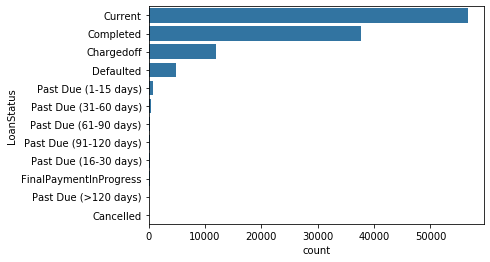

```python
# Frequency of LoanStatus original column categories
status_order = df['LoanStatus'].value_counts().index
sb.countplot(data = df, y = 'LoanStatus', color = base_color, order=status_order);
```

```python
# Create a new variable for LoanStatus_cat that consolidates the categories into
# Complete, Current, Defaulted, Chargedoff, PastDue, FinalPaymentInProgress, Cancelled
LoanStatus_cat = []
for index, row in df.iterrows():
    if 'Past Due' in row['LoanStatus']:
        LoanStatus_cat.append('PastDue')
    else:
        LoanStatus_cat.append(row['LoanStatus'])

df['LoanStatus_cat'] = pd.Series(LoanStatus_cat)
```

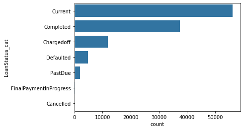

```python
# Frequency of LoanStatus consolidated categories
status_order = df['LoanStatus_cat'].value_counts().index
sb.countplot(data = df, y = 'LoanStatus_cat', color = base_color, order=status_order);
```

```python
# Create a new binary good standing loan variable, LoanStatus_good that consolidates categories into
# Favorable and Unfavorable outcomes; T, F
LoanStatus_good = []
favorable = ['Completed', 'Current', 'FinalPaymentInProgress']
for index, row in df.iterrows():
    if row['LoanStatus'] in favorable:
        LoanStatus_good.append('T')
    else:
        LoanStatus_good.append('F')

df['LoanStatus_good'] = pd.Series(LoanStatus_good)
```

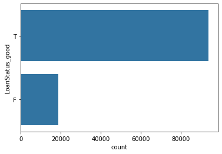

```python
# Frequency of LoanStatus consolidated into favorable, unfavorable
sb.countplot(data = df, y = 'LoanStatus_good', color=base_color);
```

**Most of the loans are Current or Complete. Unfavorable loan outcomes are far less common (PastDue, Canceled, Chargedoff). In the next section I will compare the unfavorable outcomes to several other variables to see if there are clear relationships.**

#### BorrowerRate

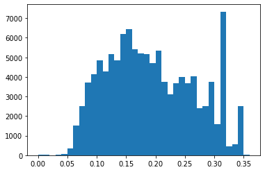

```python
# BorrowerRate Histogram
bins = np.arange(0, df['BorrowerRate'].max()+0.01, 0.01)
plt.hist(data = df, x = 'BorrowerRate', bins = bins);
```

#### EstimatedReturn

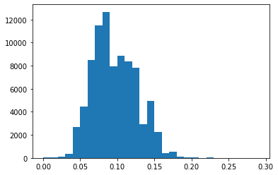

```python
# EstimatedReturn Histogram
bins = np.arange(0, df['EstimatedReturn'].max()+0.01, 0.01)
plt.hist(data = df, x = 'EstimatedReturn', bins = bins);
```

**Estimated Returns look normally distributed around 10%**

#### ProsperRating

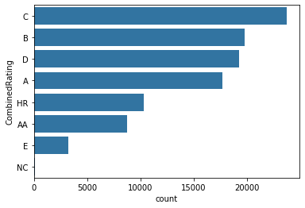

```python
# Frequency of CombinedRating
rating_order = df['CombinedRating'].value_counts().index
sb.countplot(data = df, y = 'CombinedRating', color = base_color, order=rating_order);
```

#### ProsperScore

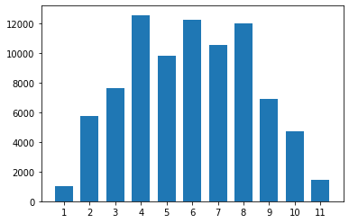

```python
# PropserScore Histogram (discrete 1-11 numeric scale)
bin_edges = np.arange(0.5, 12.5, 1)
plt.hist(data=df, x='ProsperScore', bins=bin_edges, rwidth=0.7);
ticks = [1, 2, 3, 4, 5, 6, 7, 8, 9, 10, 11]
plt.xticks(ticks, ticks);
```

**ProsperScore is a discrete variable provided by Prosper. It looks normally distributed around 6. The score may be correlated with other loan characteristics like ProsperRating**

#### ListingCategory

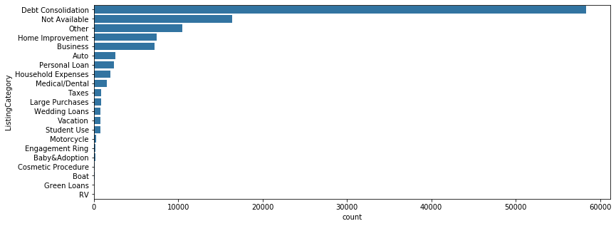

```python
# Frequency of ListingCategory
fig = plt.figure(figsize = [13,5])
listing_order = df['ListingCategory'].value_counts().index
sb.countplot(data = df, y = 'ListingCategory', color = base_color, order=listing_order);
```

**Vast majority of loans are for Debt Consolidation. I will investigate if these categories change over time or are correlated with worse loan status**

#### LoanOriginalAmount

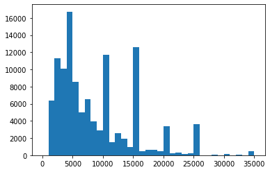

```python
# LoanOriginalAmount Histogram
bins = np.arange(0, df['LoanOriginalAmount'].max()+1000, 1000)
plt.hist(data = df, x = 'LoanOriginalAmount', bins=bins);
```

```
(500, 100000)
```

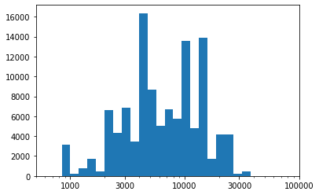

```python
# LoanOriginalAmount Histogram - Log Scale
bins = 1000 ** np.arange(-1, 3+0.1, 0.025)
ticks = [1000, 3000, 10000, 30000, 100000]
plt.hist(data = df, x = 'LoanOriginalAmount', bins=bins);
plt.xscale('log');
plt.xticks(ticks, ticks);
plt.xlim(500, 100000)
```

**Loan Amounts are right skewed with large spikes every $5000. Once placed on a log scale, they appear more normally distributed but still have high spikes**

#### LoanOriginationDate

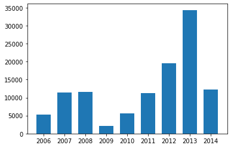

```python
# LoanOriginalDate Histogram - Years
bin_edges = np.arange(df['LoanOriginationDate'].dt.year.min()-0.5, df['LoanOriginationDate'].dt.year.max()+1.5, 1)
plt.hist(df['LoanOriginationDate'].dt.year, bins=bin_edges, rwidth=0.7);
plt.xticks(np.arange(df['LoanOriginationDate'].dt.year.min(), df['LoanOriginationDate'].dt.year.max()+1, 1));
```

**The data does not contain full year loan statistics for 2005 and 2014 so frequencies of those years are not accurate in the frequency chart. There is a dip during the 2008 financial crisis that resulted in fewer loans in 2009 and 2010. Since then there has been a steady rise and 2014 seems on pace. I will investigate if loans during the financial crisis resulted in more unfavorable loan statuses.**

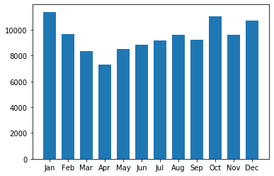

```python
# LoanOriginalDate Histogram - Months
bin_edges = np.arange(df['LoanOriginationDate'].dt.month.min()-0.5, df['LoanOriginationDate'].dt.month.max()+1.5, 1)
ticks = [ 1, 2, 3, 4, 5, 6, 7, 8, 9, 10, 11, 12]
labels = ['Jan', 'Feb', 'Mar', 'Apr', 'May', 'Jun', 'Jul', 'Aug', 'Sep', 'Oct', 'Nov', 'Dec']
plt.hist(df['LoanOriginationDate'].dt.month, bins=bin_edges, rwidth=0.7);
plt.xticks(ticks, labels);
```

**Loans are most frequent near the ends of the year in January and October through December. Frequencies may be inaccurate due to lack of complete year data in 2005 and 2014**

#### CreditScoreAvg

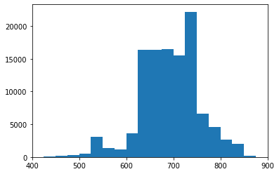

```python
# CreditScoreAvg Histogram
bins = np.arange(0, df['CreditScoreAvg'].max()+25, 25)
plt.hist(data = df, x = 'CreditScoreAvg', bins=bins);
plt.xlim(400, 900);
```

**Majority of CreditScores fall between 600 and 800. There were a few very low scores near zero that may be data input errors or coding N/A values as zero.**

**Term**

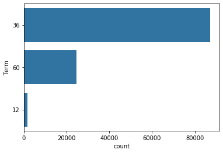

```python
# Frequency of Interest Terms
term_order = df['Term'].value_counts().index
sb.countplot(data = df, y = 'Term', color = base_color, order=term_order);
```

**Vast majority of loan terms are 36 months, very few 12 month loans. I will use a ratio to determine if loan term has any effect on loan status**

### Distribution of LoanStatus Notes:

Loan Status is our variable of most interest. We will look at correlations between variables that may suggest a loan will be in an unfavorable status (PastDue, Cancelled, Chargedoff). Most of the loans are in good standing. I created two new LoanStatus variables; LoanStatus_cat (Consolidates all PastDue categories) and LoanStatus_good (Consolidates all categories into good standing loan (T, Favorable) or not in good standing (F, Unfavorable).

### Independent feature distributions of interest

Interesting/Unusual distributions:

Operations performed in order to better visualize the data

- Created new consolidated variables for LoanStatus
- Created a single CreditScore variable
- Renamed ProsperRating (Alpha) to ProsperRating, while keeping the alpha character AA-HR rating scheme
- Renamed ListingCategory (numeric) to ListingCategory and changed all numeric values with category descriptions

## Bivariate Exploration

Look at relationships between LoanStatus and BorrowerRate, EstimatedReturn, ProsperRating, ProsperScore, ListingCategory, LoanOriginalAmount, LoanOriginationDate, CreditScoreAvg, and Term

#### BorrowerRates, LoanStatus

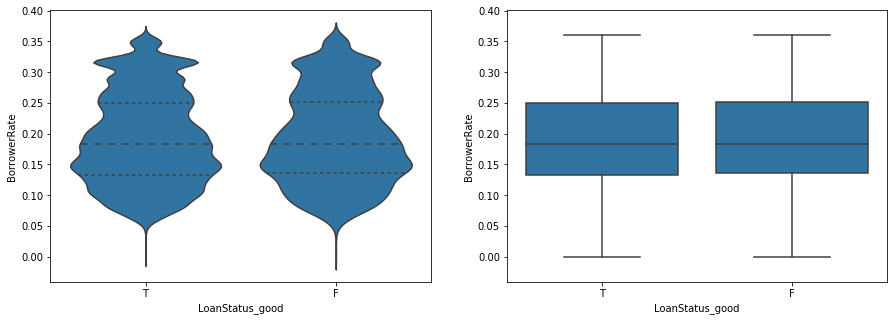

```python
# BorrowerRates by LoanStatus_good - Violin & Box plot
fig = plt.figure(figsize = [15,5])
ax1 = plt.subplot(1,2,1)
base_color = sb.color_palette()[0]
sb.violinplot(data=df, x='LoanStatus_good', y='BorrowerRate', color=base_color, inner='quartile');

ax2 = plt.subplot(1,2,2)
sb.boxplot(data=df, x='LoanStatus_good', y='BorrowerRate', color=base_color);
plt.ylim(ax1.get_ylim());
```

**BorrowerRates appear similar between good and bad loans**

#### EstimatedReturn, LoanStatus

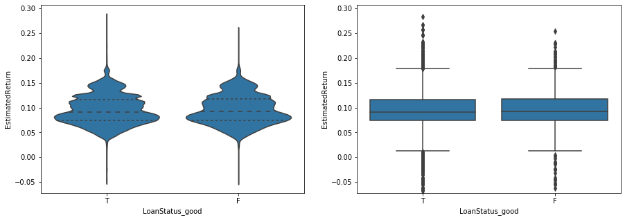

```python
# EstimatedReturn by LoanStatus_good - Violin & Box plot
fig = plt.figure(figsize = [15,5])
ax1 = plt.subplot(1,2,1)
base_color = sb.color_palette()[0]
sb.violinplot(data=df[df.EstimatedReturn > -0.05], x='LoanStatus_good', y='EstimatedReturn', color=base_color, inner='quartile');

ax2 = plt.subplot(1,2,2)
sb.boxplot(data=df, x='LoanStatus_good', y='EstimatedReturn', color=base_color);
plt.ylim(ax1.get_ylim());
```

**Estimated Returns are similar between good and bad loans. EstimatedReturn data is very spread with many outliers in the boxplot**

#### LoanOriginalAmount, EstimatedReturn

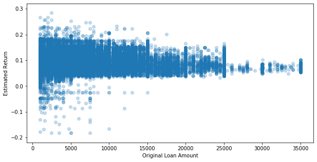

```python
# LoanOriginalAmount vs EstimatedReturn - Scatter plot
fig = plt.figure(figsize=[10,5])
sb.regplot(data = df, x = 'LoanOriginalAmount', y = 'EstimatedReturn', x_jitter = 10, scatter_kws = {'alpha': 0.25},
           fit_reg=False);
plt.xlabel('Original Loan Amount')
plt.ylabel('Estimated Return');
```

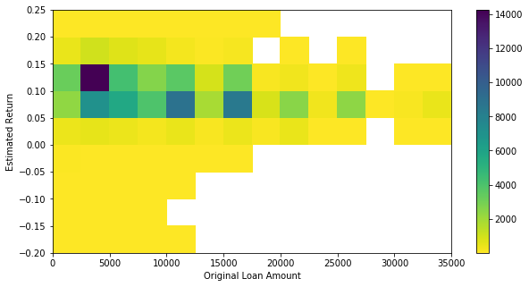

```python
# LoanOriginalAmount vs EstimatedReturn - heatmap
fig = plt.figure(figsize=[10, 5])

bins_x = np.arange(0, 37500, 2500)
bins_y = np.arange(-0.2, 0.3, 0.05)

plt.hist2d(data=df, x='LoanOriginalAmount', y='EstimatedReturn',
           bins=[bins_x, bins_y], cmap = 'viridis_r', cmin = 0.5)
plt.colorbar()
plt.xlabel('Original Loan Amount')
plt.ylabel('Estimated Return');
```

**Estimated Returns and loan amounts are grouped very tightly between 5-15% return and $2500-12500. Iterestingly, lower loan amount resulted in more cases of negative return. This may indicate high value loans are less likely to default as the borrowers are typically more qualified.**

**ProsperRating, LoanStatus**

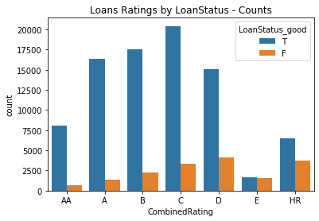

```python
# ProsperRating by LoanStatus_good - clustered bar
rating_order = ['AA','A', 'B', 'C', 'D','E', 'HR']
sb.countplot(data=df, x='CombinedRating', hue='LoanStatus_good', order=rating_order);
plt.title('Loans Ratings by LoanStatus - Counts');
```

```python
bad_loans = df.query('LoanStatus_good == "F"')
good_loans = df.query('LoanStatus_good == "T"')
```

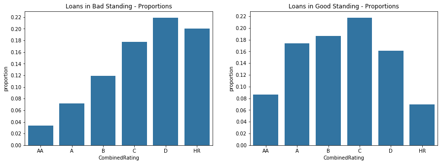

```python
# ProsperRating Proportions by LoanStatus_good - Facet bar

fig = plt.figure(figsize=[15,5])

# Derive bad_loan ticks
n_points_bad = bad_loans.shape[0]
max_count_bad = bad_loans['CombinedRating'].value_counts().max()
max_prop_bad = max_count_bad / n_points_bad

# Derive good_loan ticks
n_points_good = good_loans.shape[0]
max_count_good = good_loans['CombinedRating'].value_counts().max()
max_prop_good = max_count_good / n_points_good

max_prop = max(max_prop_good, max_prop_bad)

# generate tick mark locations and names
tick_props = np.arange(0, max_prop+0.02, 0.02)
tick_names = ['{:0.2f}'.format(v) for v in tick_props]

listing_order = ['AA', 'A', 'B', 'C', 'D', 'HR']

# create bad the plot
plt.subplot(1,2,1)
ax1 = sb.countplot(data = bad_loans, x = 'CombinedRating', color=base_color, order=listing_order)
plt.yticks(tick_props * n_points_bad, tick_names)
plt.ylabel('proportion')
plt.title('Loans in Bad Standing - Proportions')

#create the good plot
plt.subplot(1,2,2)
ax2 = sb.countplot(data = good_loans, x = 'CombinedRating', color=base_color, order=listing_order)
plt.yticks(tick_props * n_points_good, tick_names)
plt.ylabel('proportion')
plt.title('Loans in Good Standing - Proportions');
```

**Unfavorable loans are most common in D and HR grade, while C grade dominates loans in good standing. Overall there is a higher proportion of good standing loans in higher grades. This makes sense as higher ratings correspond with more qualified borrowers, however there were loans of all grades, even AA, that ended in unfavorable outcomes.**

**ListingCategory, LoanOrginalAmount**

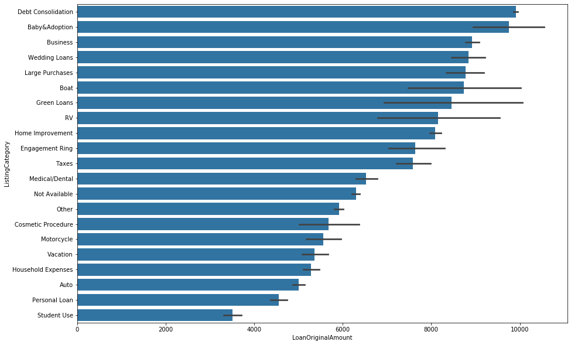

```python
# ListingCategory vs LoanOriginalAmount - Barplot
fig=plt.figure(figsize=[15,10])
listing_order = df.groupby('ListingCategory')['LoanOriginalAmount'].mean().sort_values(ascending=False).index
sb.barplot(data=df, y='ListingCategory', x='LoanOriginalAmount', color=base_color, order=listing_order);
```

**Debt Consolidation dominated the number of loans taken out, however Average Loan Amounts for Debt Consolidation are much closer to the other Categories.**

**ListingCategory, LoanStatus**

```python
# Store a summary of ListingCategory by Proportions for good and bad loans
listing_props = df['LoanStatus_good'].groupby(df['ListingCategory']).value_counts(normalize=True)\
.rename('Proportion').reset_index()
```

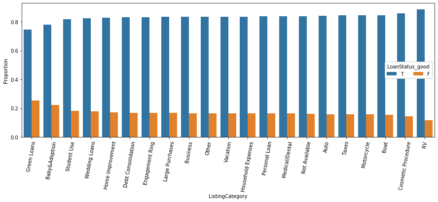

```python
# ListingCategory by LoanStatus_good - clustered bar (Proportions)
fig=plt.figure(figsize=[15,5])
listing_order = listing_props.query('LoanStatus_good == "T"').sort_values(by='Proportion')['ListingCategory']
ax = sb.barplot(data=listing_props, x='ListingCategory', y='Proportion', hue='LoanStatus_good', order=listing_order);
plt.xticks(rotation=80);
ax.legend(loc = 5, ncol = 3, framealpha = 1, title = 'LoanStatus_good');
```

**The proportion of bad to good loans is varies from ~10-25% depending on loan category. Green Loans and Baby&Adoption categories lead in proportion of loans going bad.**

**ProsperScore, LoanStatus**

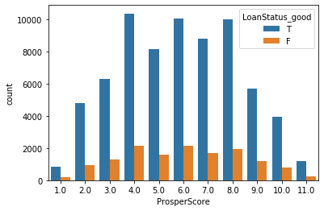

```python
# ProsperScore frequency by LoanStatus_good - clustered bar
sb.countplot(data=df, x='ProsperScore', hue='LoanStatus_good');
```

**Bad loans have the same distribution as good loans for ProsperScore**

**ProsperScore, LoanOriginalAmount**

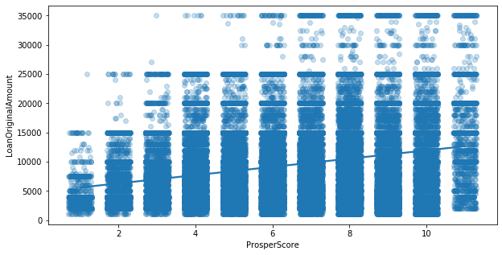

```python
# ProsperScore vs LoanOriginalAmount - Scatter plot
fig = plt.figure(figsize=[10,5])
sb.regplot(data = df, x = 'ProsperScore', y = 'LoanOriginalAmount', x_jitter = 0.3, scatter_kws = {'alpha': 0.25},
           fit_reg=True);
plt.xlabel('ProsperScore')
plt.ylabel('LoanOriginalAmount');
```

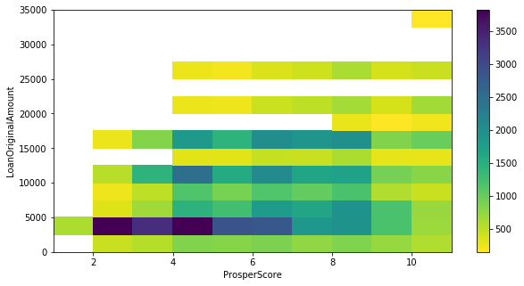

```python
# ProsperScore vs LoanOriginalAmount- heatmap
fig = plt.figure(figsize=[10, 5])

bins_y = np.arange(0, 37500, 2500)
bins_x = np.arange(1, 12, 1)

plt.hist2d(data=df, x='ProsperScore', y='LoanOriginalAmount',
           bins=[bins_x, bins_y], cmap = 'viridis_r', cmin = 150)
plt.colorbar()
plt.xlabel('ProsperScore')
plt.ylabel('LoanOriginalAmount');
```

**Lower ProsperScore loans are usually lower dollar amount. There is a slight positive correlation between the Score and OriginalLoanAmount**

**LoanOriginationDate, LoanStatus**

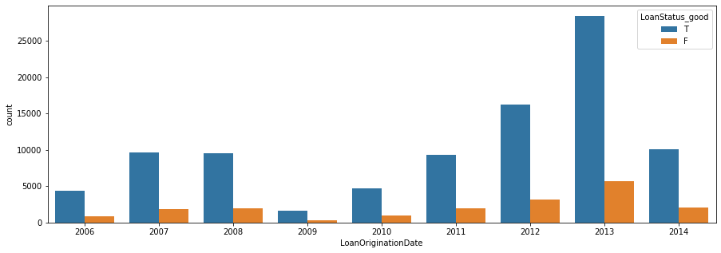

```python
# LoanOriginationDate by LoanStatus_good - clustered bar (Frequency)
fig=plt.figure(figsize=[15,5])
sb.countplot(df['LoanOriginationDate'].dt.year, hue=df['LoanStatus_good']);
```

```python
# Store a summary of LoanOriginationDate Years by Proportions for good and bad loans
year_props = df['LoanStatus_good'].groupby(df['LoanOriginationDate'].dt.year).value_counts(normalize=True)\
.rename('Proportion').reset_index()
```

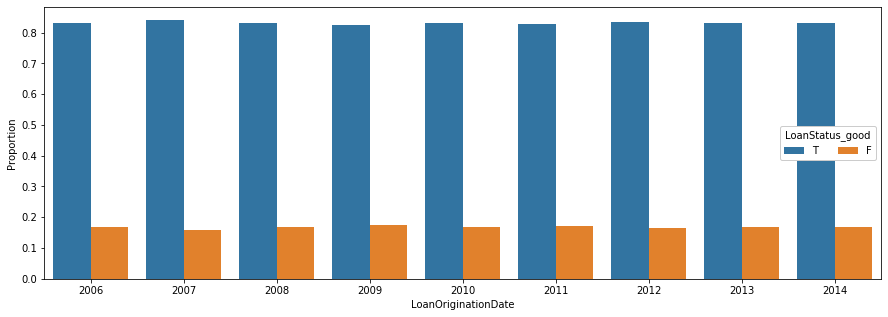

```python
# LoanOriginationDate by LoanStatus_good - clustered bar (Proportions)
fig=plt.figure(figsize=[15,5])
year_order = [2006, 2007, 2008, 2009, 2010, 2011, 2012, 2013, 2014]
ax = sb.barplot(data=year_props, x='LoanOriginationDate', y='Proportion', hue='LoanStatus_good', order=year_order);

ax.legend(loc = 5, ncol = 2, framealpha = 1, title = 'LoanStatus_good');
```

**Bad loans follow the same distribution and have almost identical proportions amongst all years of data. I assumed there would be more unfavorable loans during economic crisis. This may be because Prosper was more stringent about loans or we need to break down the timeline further.**

**CreditScoreAvg, LoanStatus**

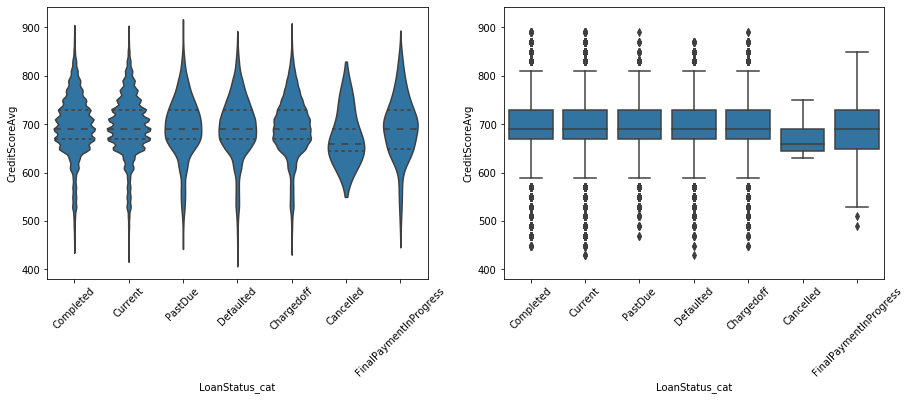

```python
# CreditScoreAvg by LoanStatus_good - Violin & Box plot
fig = plt.figure(figsize = [15,5])
ax1 = plt.subplot(1,2,1)
base_color = sb.color_palette()[0]
sb.violinplot(data=df[df.CreditScoreAvg > 200], x='LoanStatus_cat', y='CreditScoreAvg', color=base_color, inner='quartile');
plt.xticks(rotation=45)

ax2 = plt.subplot(1,2,2)
sb.boxplot(data=df, x='LoanStatus_cat', y='CreditScoreAvg', color=base_color);
plt.ylim(ax1.get_ylim());
plt.xticks(rotation=45)
```

**Credit Scores are similar between good and bad loans. This is suprising because Credit Score is often associated as connected to qualification of paying a loan.**

**Term, LoanStatus**

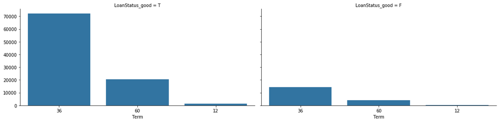

```python
# Term proportion over LoanStatus_good - Facet countplot proportions

g = sb.FacetGrid(data = df, col = 'LoanStatus_good', height=4, aspect=2)

term_order = df['Term'].value_counts().index

g.map(sb.countplot, 'Term', order=term_order);
```

**Loan status seems to effect all 3 loan terms about the same**

### Talk about some of the relationships you observed in this part of the investigation. How did the feature(s) of interest vary with other features in the dataset?

**Relationship investigations:**

BorrowerRate & EstimatedReturn have similar distributions between favorable, unfavorable loans

ProsperScore, Year, and Term seemed to have no observed correlation with LoanStatus

**Interesting investigations, areas to focus further:**

CreditScoreAvg distributions are similar among all categories of LoanStatus. I would hypothesize that lower Credit Scores would reflect more negative loan outcomes but our hypthesis was not supported by only looking at credit score by loan status. Only cancelled loans showed a decline of around 30 points in median credit score. We should break Credit Scores down further by loan rating and category to see if there are further insights.

CombinedRating showed there are more poor quality loans that resulted in unfavorable outcomes.

Listing Category showed some variations from 10% to 25% of loans resulting in unfavorable outcomes.

### Did you observe any interesting relationships between the other features (not the main feature(s) of interest)?

More EstimatedReturns were negative when LoanOriginalAmount was smaller but the majority are grouped tightly together

Debt Consolidation recieves the most loans and most dollar amount on average

## Multivariate Exploration

> Create plots of three or more variables to investigate your data even further. Make sure that your investigations are justified, and follow from your work in the previous sections.

**LoanStatus, CombinedRating, CreditScoreAvg**

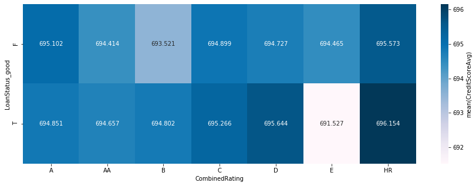

```python
fig=plt.figure(figsize=[15,5])
cat_means = df.groupby(['CombinedRating', 'LoanStatus_good']).mean()['CreditScoreAvg']
cat_means.drop('NC', axis=0, inplace=True)
cat_means = cat_means.reset_index(name = 'CreditScoreAvg_avg')
cat_means = cat_means.pivot(index = 'LoanStatus_good', columns = 'CombinedRating',
                            values = 'CreditScoreAvg_avg')
sb.heatmap(cat_means, annot = True, fmt = '.3f', cmap='PuBu', cbar_kws = {'label' : 'mean(CreditScoreAvg)'})
```

**Credit Scores are lowest in E rated, good loans, and highest in High Risk rated good loans. Bad loans are within a few points of their good loan counterparts in each rating category.**

**LoanStatus, ListingCategory, CreditScoreAvg**

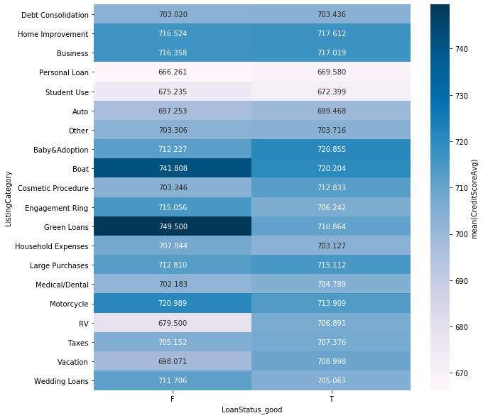

```python
fig=plt.figure(figsize=[10,10])
cat_means = df.groupby(['ListingCategory', 'LoanStatus_good']).mean()['CreditScoreAvg']
cat_means.drop('Not Available', axis=0, inplace=True)
cat_means = cat_means.reset_index(name = 'CreditScoreAvg_avg')
cat_means = cat_means.pivot(index = 'ListingCategory', columns = 'LoanStatus_good',
                            values = 'CreditScoreAvg_avg')
sb.heatmap(cat_means, annot = True, fmt = '.3f', cmap='PuBu', cbar_kws = {'label' : 'mean(CreditScoreAvg)'});
```

**Green Loans that turn unfavorable have the highest average Credit Score. Green loans represent the highest proportion of bad loans in listing categories. It seems credit score's have little to do with a loan turning unfavorable**

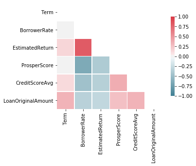

```python
# Correlation heatmap
corr = df[['Term', 'BorrowerRate', 'EstimatedReturn', 'ProsperScore', 'CreditScoreAvg',
           'LoanOriginalAmount']].corr()
mask = np.triu(np.ones_like(corr, dtype=np.bool))
cmap = sb.diverging_palette(220, 10, as_cmap=True)

sb.heatmap(corr, mask=mask, square=True, cmap=cmap, vmax=1, vmin=-1, center=0, linewidths=.5, cbar_kws={"shrink": .75});
```

**EstimatedReturn and BorrowerRate have a high positive correlation while ProsperScore and BorrowerRate seem to have a high negative correlation.**

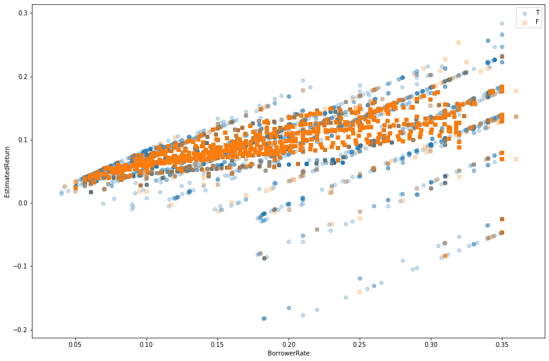

```python
# Scatter plot with markers
fig = plt.figure(figsize=[15,10])
cat_markers = [['T', 'o'],
               ['F', 's']]

sampled = df[df.CreditScoreAvg > 400]
sampled = sampled.sample(frac=1, replace=False, random_state=1234)

for cat, marker in cat_markers:
    df_cat = sampled[sampled['LoanStatus_good'] == cat]
    sb.regplot(data = df_cat, x = 'BorrowerRate', y = 'EstimatedReturn', marker = marker,
               scatter_kws = {'alpha': 0.25}, fit_reg=False)
plt.legend(['T','F']);
```

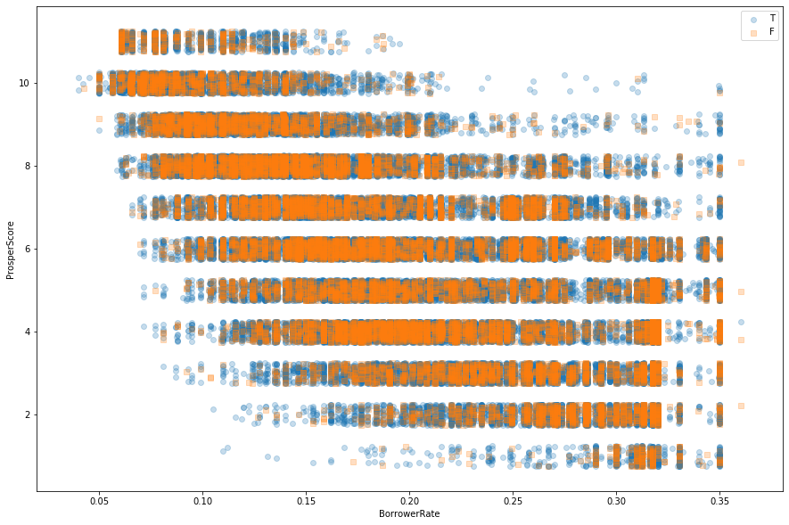

```python
# Scatter plot with markers
fig = plt.figure(figsize=[15,10])
cat_markers = [['T', 'o'],
               ['F', 's']]

sampled = df[df.CreditScoreAvg > 400]
sampled = sampled.sample(frac=1, replace=False, random_state=1234)

for cat, marker in cat_markers:
    df_cat = sampled[sampled['LoanStatus_good'] == cat]
    sb.regplot(data=df_cat, x='BorrowerRate', y='ProsperScore', y_jitter=0.25, marker=marker,
               scatter_kws = {'alpha': 0.25}, fit_reg=False)
plt.legend(['T','F']);
```

**EstimatedReturn & BorrowerRate, and ProsperScore & BorrowerRate are highly correlated however, they do not have have correlation together with LoanStatus**

**Although EstimatedReturn and BorrowerRate are highly correlated they don't seem to trend with LoanStatus in a meaningful way.**

### Talk about some of the relationships you observed in this part of the investigation. Were there features that strengthened each other in terms of looking at your feature(s) of interest?

The correlation heatmap shows EstimatedReturn & BorrowerRate have a high positive correlation, and ProsperScore & BorrowerRate have a high negative correlation. When we pair them with LoanStatus however, we don't see a strong connection.

```python
df.to_csv('prosperloanData_visclean.csv')
```